# Final Project Advanced Modeling

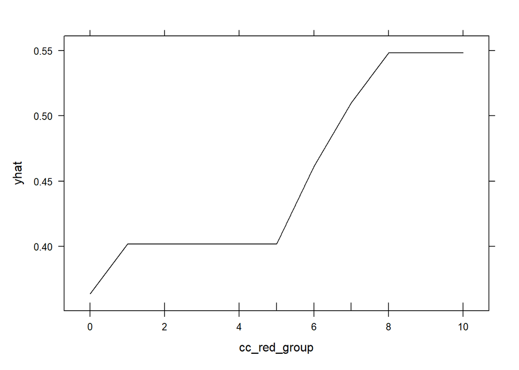

```r
partial(gbmFit, pred.var = "cc_red_group", which.class=2, plot = TRUE, prob=TRUE, rug = TRUE)
```

For the Gradient Boosting model, the variable importance plot indicates `cc_impact`as the strongest predictor, followed by `worry_cc`, `cc_red_group`, `cc_real`, and `age.` Other predictors show smaller influence.

The partial dependence plots for Gradient Boosting reveal:

- `cc_impact`: similar to Random Forest, belief probability decreases as perceived impact shifts towards “better” (higher scores), with a clear drop between 0 and around 5, then a slight increase after 8.
- `worry_cc`: increasing worry about climate change corresponds to a rising probability of belief, especially notable from levels 3 to 5.
- `cc_red_group`: the belief probability remains low at lower values but increases sharply beyond a threshold (~5), indicating greater belief among those more engaged with climate change reduction groups.

For comparison, we can check a pcp for the LDA model and the `cc_impact` variable, as it also appeared in the Random Forest and Gradient Boosting models.

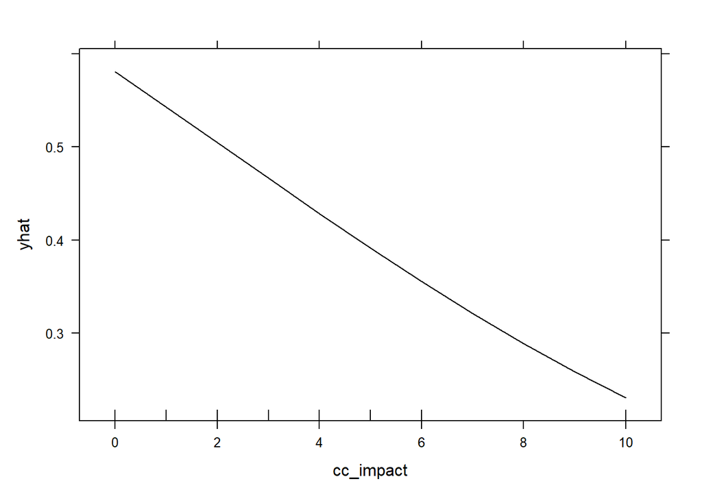

```r
partial(ldaFit, pred.var = "cc_impact", which.class=2, plot = TRUE, prob=TRUE, rug = TRUE)
```